# Task 5

Paulius Kostickis

Sunday, March 20, 2016

Užduotis: Pinigų paklausa. Šioje užduotyje reikia atlikti tiesinę regresiją. Pakete dynlm yra duomenų masyvas M1Germany - ten yra ir jo aprašymas. Iš turimų duomenų sudarykite ir įvertinkite tiesinę regresiją, kurios endoneninis kintamasis yra logm1. Lygtis būtų naudojama prognozuoti pinigų kiekį artimiausiam laikotarpiui į prieki remiantis dabartine situacija. Taigi prognozės sudarymui lygtis gali naudoti tik tuos duomenis, kurie būtų žinomi prognozavimo momentu.

```r
library(dynlm)
library(knitr)
data=ts(M1Germany)
logprice = ts(M1Germany$logprice)
logm1 =ts(M1Germany$logm1)
loggnp =ts(M1Germany$loggnp)
interest=ts(M1Germany$interest)
```

Įvairūs grafikai

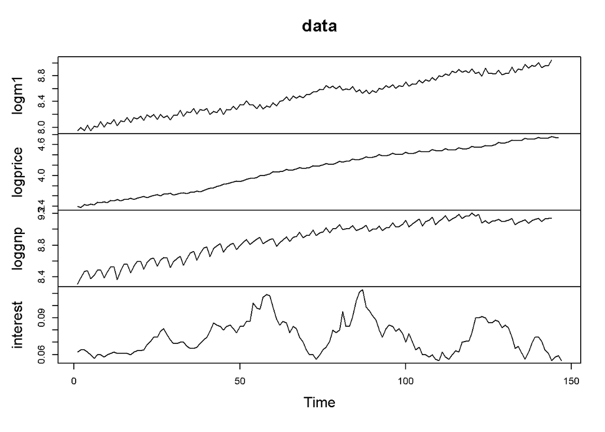

```r
plot(data)
```

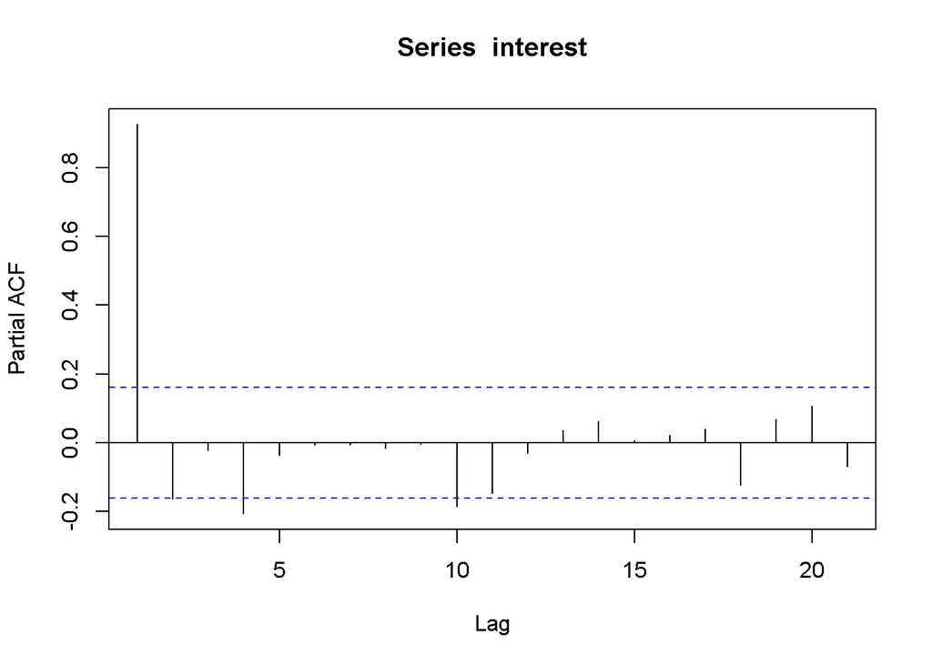

```r
pacf(interest)
```

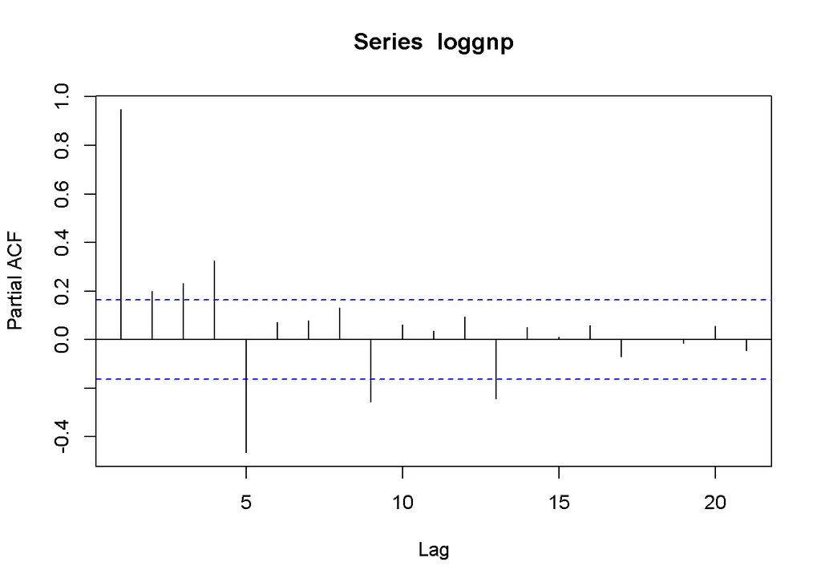

```r
pacf(loggnp, na.action=na.omit)
```

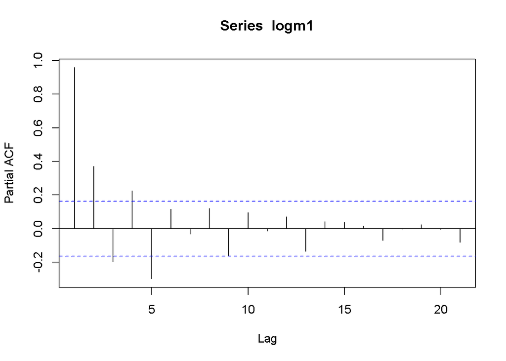

```r
pacf(logm1,na.action=na.omit)
```

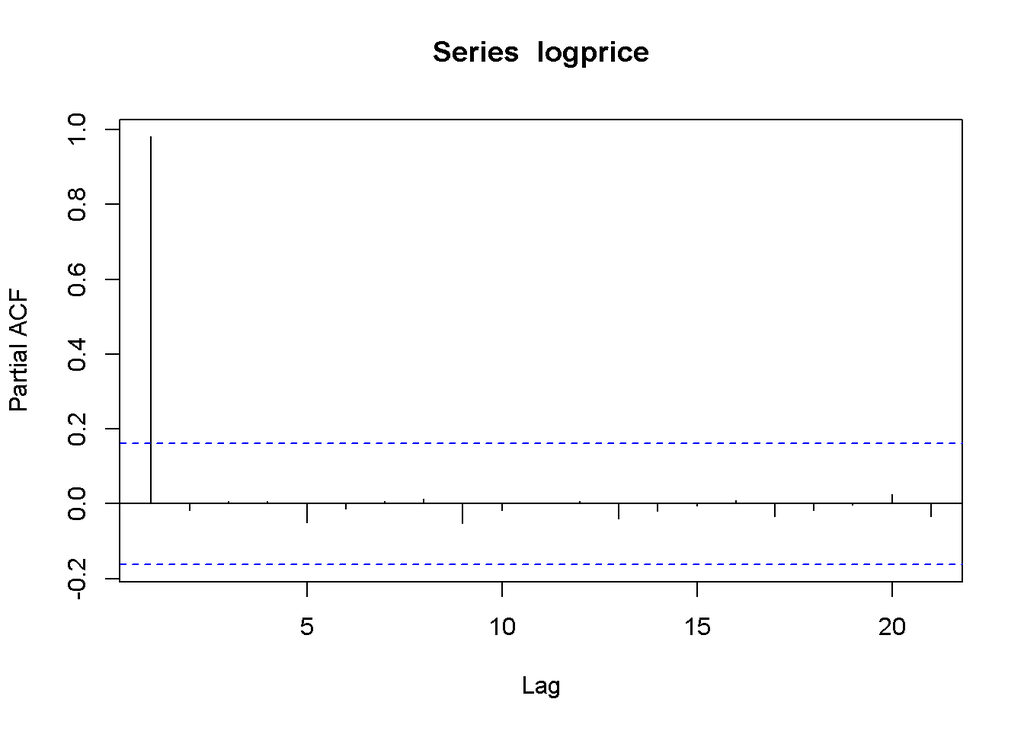

```r
pacf(logprice,na.action=na.omit)
```

Palūkanų norma neturi ryškaus trendo. Taip tai galėtume spėti, kad turi tiesioginį ryšį su pinigų paklausa - kuo didesnės palūkanos, tuo mažesnė pinigų paklausa.

BVP turi akivaizdu trendą, jį pašalinsime paimdami BVP skirtumą vietoj paprasto BVP. BVP augimas turėtų didinti pinigų paklausą.

Galėtume spėti, kad praėjusių laikotarpių pinigų paklausa gali prognozuoti ateities paklausą.

Modelių kūrimas:

```r
mod1=dynlm(logm1~L(logprice,3)+d(L(loggnp,2))+d(interest) ,data=data)
mod2=dynlm(logm1~L(logm1^2,1) +L(logprice,3)+d(L(loggnp,1))+L(interest,1) ,data=data)
mod3=dynlm(logm1~L(logm1^2,1) +L(logprice,1)+d(L(loggnp,2))+L(interest,2),data=data)
mod4=dynlm(logm1~L(logm1^2,1) +L(logprice,3)+d(L(loggnp,3))+L(interest,2) ,data=data)
mod5=dynlm(logm1~L(logm1,1) +L(logprice,3)+d(L(loggnp,2))+L(interest,2) ,data=data)
mod6=dynlm(logm1~L(logm1,1) +L(logprice,1)+d(L(loggnp,2))+L(interest,3) ,data=data)
```

Ir pagal AIC mod4 geriausias

```r
AIC(mod1)
```

```
## [1] -421.9432
```

```r
AIC(mod2)
```

```
## [1] -493.1158
```

```r
AIC(mod3)
```

```
## [1] -477.5154
```

```r
AIC(mod4)
```

```
## [1] -535.1348
```

```r
AIC(mod5)
```

```
## [1] -497.9031
```

```r
AIC(mod6)
```

```
## [1] -478.7594
```

```r
summary(mod1)
```

```
##
## Time series regression with "ts" data:
## Start = 4, End = 144
##
## Call:
## dynlm(formula = logm1 ~ L(logprice, 3) + d(L(loggnp, 2)) + d(interest),
##     data = data)
##
## Residuals:
##       Min        1Q    Median        3Q       Max
## -0.140082 -0.032072  0.004291  0.033891  0.121014
##
## Coefficients:
##                 Estimate Std. Error t value Pr(>|t|)
## (Intercept)      5.62679    0.04529 124.242  < 2e-16 ***
## L(logprice, 3)   0.70031    0.01097  63.854  < 2e-16 ***
## d(L(loggnp, 2))  0.24306    0.07861   3.092  0.00241 **
## d(interest)      2.65916    0.90591   2.935  0.00391 **
## ---
## Signif. codes:  0 '***' 0.001 '**' 0.01 '*' 0.05 '.' 0.1 ' ' 1
##
## Residual standard error: 0.05306 on 137 degrees of freedom
## Multiple R-squared:  0.9676, Adjusted R-squared:  0.9669
## F-statistic:  1363 on 3 and 137 DF,  p-value: < 2.2e-16
```

```r
summary(mod2)
```

```
##
## Time series regression with "ts" data:
## Start = 4, End = 144
##
## Call:
## dynlm(formula = logm1 ~ L(logm1^2, 1) + L(logprice, 3) + d(L(loggnp,
##     1)) + L(interest, 1), data = data)
##
## Residuals:
##       Min        1Q    Median        3Q       Max
## -0.087714 -0.033083 -0.000276  0.028620  0.098581
##
## Coefficients:
##                  Estimate Std. Error t value Pr(>|t|)
## (Intercept)      5.105543   0.112385  45.429  < 2e-16 ***
## L(logm1^2, 1)    0.026342   0.004118   6.396 2.38e-09 ***
## L(logprice, 3)   0.389642   0.050034   7.788 1.56e-12 ***
## d(L(loggnp, 1)) -0.255461   0.065034  -3.928 0.000136 ***
## L(interest, 1)  -1.386839   0.297420  -4.663 7.36e-06 ***
## ---
## Signif. codes:  0 '***' 0.001 '**' 0.01 '*' 0.05 '.' 0.1 ' ' 1
##
## Residual standard error: 0.04109 on 136 degrees of freedom
## Multiple R-squared:  0.9807, Adjusted R-squared:  0.9801
## F-statistic:  1728 on 4 and 136 DF,  p-value: < 2.2e-16
```

```r
summary(mod3)
```

```
##
## Time series regression with "ts" data:
## Start = 4, End = 144
##
## Call:
## dynlm(formula = logm1 ~ L(logm1^2, 1) + L(logprice, 1) + d(L(loggnp,
##     2)) + L(interest, 2), data = data)
##
## Residuals:
##       Min        1Q    Median        3Q       Max
## -0.098082 -0.028811  0.004804  0.030947  0.131865
##
## Coefficients:
##                  Estimate Std. Error t value Pr(>|t|)
## (Intercept)      5.235091   0.126021  41.541  < 2e-16 ***
## L(logm1^2, 1)    0.020447   0.004615   4.430 1.92e-05 ***
## L(logprice, 1)   0.467587   0.056581   8.264 1.12e-13 ***
## d(L(loggnp, 2))  0.161714   0.065526   2.468   0.0148 *
## L(interest, 2)  -1.850970   0.352357  -5.253 5.63e-07 ***
## ---
## Signif. codes:  0 '***' 0.001 '**' 0.01 '*' 0.05 '.' 0.1 ' ' 1
##
## Residual standard error: 0.04342 on 136 degrees of freedom
## Multiple R-squared:  0.9784, Adjusted R-squared:  0.9778
## F-statistic:  1543 on 4 and 136 DF,  p-value: < 2.2e-16
```

```r
summary(mod4)
```

```
##
## Time series regression with "ts" data:
## Start = 5, End = 144
##
## Call:
## dynlm(formula = logm1 ~ L(logm1^2, 1) + L(logprice, 3) + d(L(loggnp,
##     3)) + L(interest, 2), data = data)
##
## Residuals:
##       Min        1Q    Median        3Q       Max
## -0.071803 -0.022607 -0.004463  0.020387  0.111676
##
## Coefficients:
##                  Estimate Std. Error t value Pr(>|t|)
## (Intercept)      5.202309   0.098718  52.699  < 2e-16 ***
## L(logm1^2, 1)    0.023118   0.003571   6.473 1.64e-09 ***
## L(logprice, 3)   0.427818   0.043480   9.839  < 2e-16 ***
## d(L(loggnp, 3)) -0.432860   0.052776  -8.202 1.64e-13 ***
## L(interest, 2)  -1.647949   0.268123  -6.146 8.37e-09 ***
## ---
## Signif. codes:  0 '***' 0.001 '**' 0.01 '*' 0.05 '.' 0.1 ' ' 1
##
## Residual standard error: 0.03492 on 135 degrees of freedom
## Multiple R-squared:  0.9859, Adjusted R-squared:  0.9855
## F-statistic:  2360 on 4 and 135 DF,  p-value: < 2.2e-16
```

```r
summary(mod5)
```

```
##
## Time series regression with "ts" data:
## Start = 4, End = 144
##
## Call:
## dynlm(formula = logm1 ~ L(logm1, 1) + L(logprice, 3) + d(L(loggnp,
##     2)) + L(interest, 2), data = data)
##
## Residuals:
##       Min        1Q    Median        3Q       Max
## -0.091396 -0.030295  0.001108  0.028543  0.125290
##
## Coefficients:
##                 Estimate Std. Error t value Pr(>|t|)
## (Intercept)      4.02775    0.40180  10.024  < 2e-16 ***
## L(logm1, 1)      0.30204    0.06934   4.356 2.59e-05 ***
## L(logprice, 3)   0.49810    0.04968  10.025  < 2e-16 ***
## d(L(loggnp, 2))  0.24234    0.05991   4.045 8.73e-05 ***
## L(interest, 2)  -1.82502    0.30344  -6.014 1.57e-08 ***
## ---
## Signif. codes:  0 '***' 0.001 '**' 0.01 '*' 0.05 '.' 0.1 ' ' 1
##
## Residual standard error: 0.04039 on 136 degrees of freedom
## Multiple R-squared:  0.9813, Adjusted R-squared:  0.9808
## F-statistic:  1789 on 4 and 136 DF,  p-value: < 2.2e-16
```

```r
summary(mod6)
```

```
##
## Time series regression with "ts" data:
## Start = 4, End = 144
##
## Call:
## dynlm(formula = logm1 ~ L(logm1, 1) + L(logprice, 1) + d(L(loggnp,
##     2)) + L(interest, 3), data = data)
##
## Residuals:
##       Min        1Q    Median        3Q       Max
## -0.096007 -0.034519  0.005427  0.030363  0.135074
##
## Coefficients:
##                 Estimate Std. Error t value Pr(>|t|)
## (Intercept)      4.11731    0.48691   8.456 3.83e-14 ***
## L(logm1, 1)      0.28561    0.08425   3.390 0.000915 ***
## L(logprice, 1)   0.51355    0.06102   8.417 4.77e-14 ***
## d(L(loggnp, 2))  0.13560    0.06592   2.057 0.041590 *
## L(interest, 3)  -2.12606    0.36994  -5.747 5.70e-08 ***
## ---
## Signif. codes:  0 '***' 0.001 '**' 0.01 '*' 0.05 '.' 0.1 ' ' 1
##
## Residual standard error: 0.04323 on 136 degrees of freedom
## Multiple R-squared:  0.9786, Adjusted R-squared:  0.978
## F-statistic:  1557 on 4 and 136 DF,  p-value: < 2.2e-16
```

Nors pagal AIC geriausias modelis yra mod4,bet pagal BVP prieaugio įtaką, esu linkęs rinktis mod6, nes jame BVP priaugis didina pinigų paklausą.(mod4 modelyje buvęs prieš 3 metus BVP prieaugis mažina paklausą)

Su reikšmingumo lygmeniu 0.05 negalime atmesti, kad modelio mod4 normalios liekanos. Tačiau paėmus reikšmingumo lygį 0.1, galėtume sakyti, jog liekanos nėra normalios modelio mod4. Matoma “sunki uodega” liekanų į dešinę pusę. Mod6 (mano pasirinktu kaip geriausiu modeliu) liekanų skirstinis atrodo kaip normalusis ir testo p.value daug didesnis nei mod4 modelio.

```r
shapiro.test(mod4$res) #su reikšmingumo lygmeniu 0,05 negalime atmesti, kad normalios liekanos.
```

```
##
##  Shapiro-Wilk normality test
##
## data:  mod4$res
## W = 0.9827, p-value = 0.07415
```

```r
shapiro.test(mod6$res) #su reikšmingumo lygmeniu 0,05 negalime atmesti, kad normalios liekanos.
```

```
##
##  Shapiro-Wilk normality test
##
## data:  mod6$res
## W = 0.9872, p-value = 0.2187
```

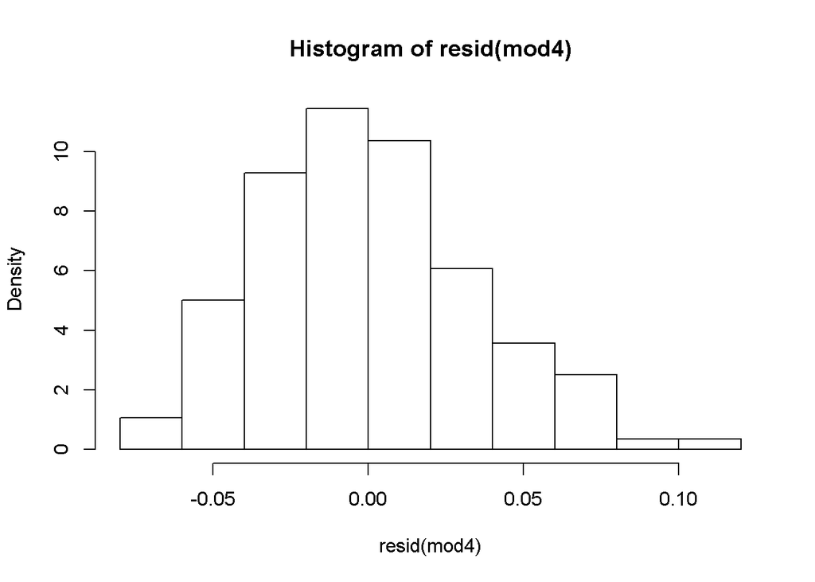

```r
hist(resid(mod4), probability = TRUE)
```

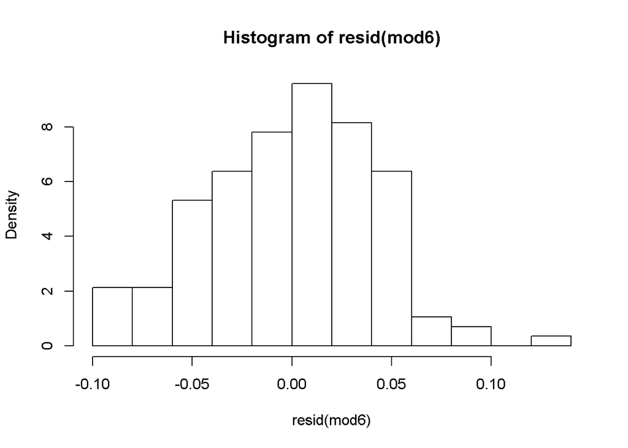

```r
hist(resid(mod6), probability = TRUE)
```

Pasirinktas mod6 modelis(nors ir ne su mažiausiu AIC iš buvusių modelių):

```r
summary(mod6)
```

```
##
## Time series regression with "ts" data:
## Start = 4, End = 144
##
## Call:
## dynlm(formula = logm1 ~ L(logm1, 1) + L(logprice, 1) + d(L(loggnp,
##     2)) + L(interest, 3), data = data)
##
## Residuals:
##       Min        1Q    Median        3Q       Max
## -0.096007 -0.034519  0.005427  0.030363  0.135074
##
## Coefficients:
##                 Estimate Std. Error t value Pr(>|t|)
## (Intercept)      4.11731    0.48691   8.456 3.83e-14 ***
## L(logm1, 1)      0.28561    0.08425   3.390 0.000915 ***
## L(logprice, 1)   0.51355    0.06102   8.417 4.77e-14 ***
## d(L(loggnp, 2))  0.13560    0.06592   2.057 0.041590 *
## L(interest, 3)  -2.12606    0.36994  -5.747 5.70e-08 ***
## ---
## Signif. codes:  0 '***' 0.001 '**' 0.01 '*' 0.05 '.' 0.1 ' ' 1
##
## Residual standard error: 0.04323 on 136 degrees of freedom
## Multiple R-squared:  0.9786, Adjusted R-squared:  0.978
## F-statistic:  1557 on 4 and 136 DF,  p-value: < 2.2e-16
```